# Reproducible Research: Peer Assessment 1

# reproducible research coursera project

```r
library(tidyverse)
library(lubridate)
library(VIM)
library(knitr)
```

first, I created the data file. Then I unziped the activity monitoring data file and load the activity data using the read.csv function.

```r
if (!file.exists("data")) {
        dir.create("data")
}

Url <- "https://d396qusza40orc.cloudfront.net/repdata%2Fdata%2Factivity.zip"
download.file(Url, destfile = "./data/monitoringdata.zip", method = "curl")
unzip( "./data/monitoringdata.zip", exdir = "./data")

act <- read.csv("./data/activity.csv")
DT::datatable(act)
```

|  | steps | date | interval |
| --- | --- | --- | --- |
| 1 |  | 2012-10-01 | 0 |
| 2 |  | 2012-10-01 | 5 |
| 3 |  | 2012-10-01 | 10 |
| 4 |  | 2012-10-01 | 15 |
| 5 |  | 2012-10-01 | 20 |
| 6 |  | 2012-10-01 | 25 |
| 7 |  | 2012-10-01 | 30 |
| 8 |  | 2012-10-01 | 35 |
| 9 |  | 2012-10-01 | 40 |
| 10 |  | 2012-10-01 | 45 |

[output cut: 17558 more lines]

## What is mean total number of steps taken per day?

1. Calculate the total number of steps taken per day

```r
act %>% group_by(date) %>%
        summarize(sumsteps=sum(steps, na.rm = T))
```

```
## # A tibble: 61 x 2
##    date       sumsteps
##    <fct>         <int>
##  1 2012-10-01        0
##  2 2012-10-02      126
##  3 2012-10-03    11352
##  4 2012-10-04    12116
##  5 2012-10-05    13294
##  6 2012-10-06    15420
##  7 2012-10-07    11015
##  8 2012-10-08        0
##  9 2012-10-09    12811
## 10 2012-10-10     9900
## # ... with 51 more rows
```

2. Make a histogram of the total number of steps taken each day

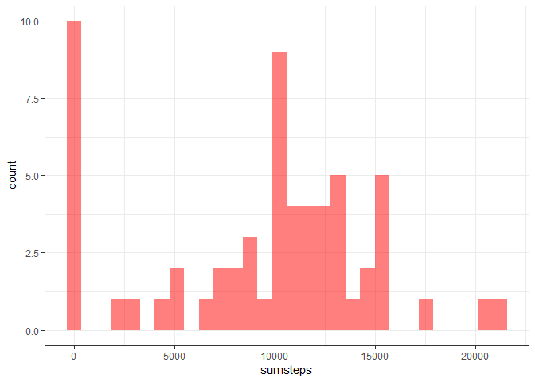

```r
act %>% group_by(date) %>%
        summarize(sumsteps=sum(steps, na.rm = T)) %>%
        ggplot(aes(x=sumsteps))+geom_histogram(bins = 30, fill="red", alpha=0.5)+
        theme_bw()
```

3. Calculate and report the mean and median of the total number of steps taken per day

```r
act %>% group_by(date) %>%
        summarize(sumsteps=sum(steps, na.rm = T)) %>%
        summarize(mean=mean(sumsteps, na.rm = T), median=median(sumsteps, na.rm = T))
```

```
## # A tibble: 1 x 2
##    mean median
##   <dbl>  <int>
## 1 9354.  10395
```

## What is the average daily activity pattern?

1. Make a time series plot of the 5-minute interval (x-axis) and the average number of steps taken, averaged across all days (y-axis)

```r
glimpse(act)
```

```
## Observations: 17,568
## Variables: 3
## $ steps    <int> NA, NA, NA, NA, NA, NA, NA, NA, NA, NA, NA, NA, NA, N...
## $ date     <fct> 2012-10-01, 2012-10-01, 2012-10-01, 2012-10-01, 2012-...
## $ interval <int> 0, 5, 10, 15, 20, 25, 30, 35, 40, 45, 50, 55, 100, 10...
```

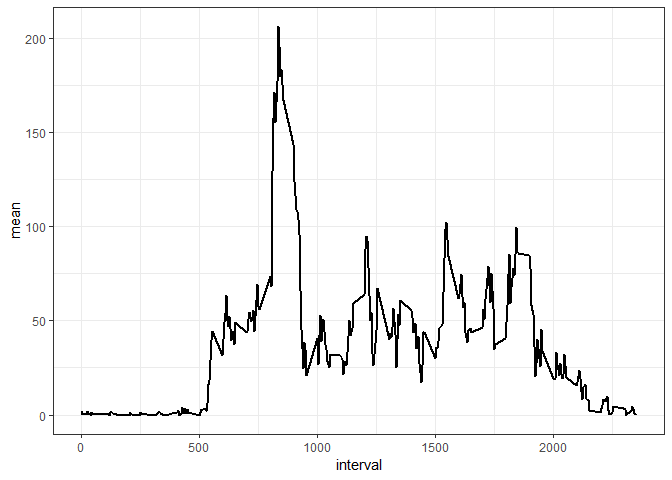

```r
act$date <- lubridate::ymd(act$date)
act %>% group_by(interval) %>%
        summarize(mean=mean(steps, na.rm=TRUE)) %>%
        ggplot(aes(x=interval, y=mean))+
        geom_line(size=1)+
        theme_bw()
```

2. Which 5-minute interval, on average across all the days in the dataset, contains the maximum number of steps?

```r
act %>% group_by(interval) %>%
        summarize(intervalmean=mean(steps, na.rm = TRUE)) %>%
        filter(intervalmean==max(intervalmean))
```

```
## # A tibble: 1 x 2
##   interval intervalmean
##      <int>        <dbl>
## 1      835         206.
```

## Imputing missing values

1. Calculate and report the total number of missing values in the dataset

```r
sum(is.na(act))
```

```
## [1] 2304
```

2. Devise a strategy for filling in all of the missing values in the dataset. I selected the method of mean imputation because missing value exist only steps variable

```r
na.count=apply(act, 2, function(x) sum(is.na(x)))
na.count
```

```
##    steps     date interval
##     2304        0        0
```

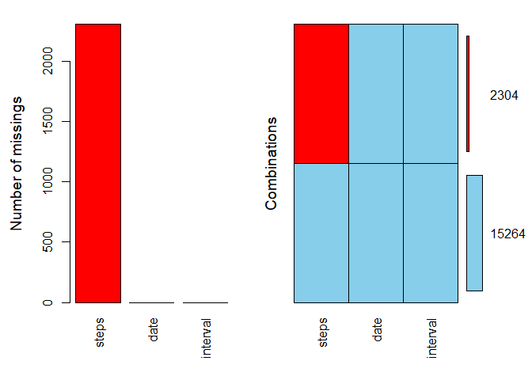

```r
library(VIM)
aggr(act, prop=FALSE, numbers=TRUE)
```

```r
mean(act$steps, na.rm = T)
```

```
## [1] 37.3826
```

3. Create a new dataset that is equal to the original dataset but with the missing data filled in

```r
act$steps <- ifelse(is.na(act$steps), 37.3826, act$steps)
table(is.na(act$steps))
```

```
##
## FALSE
## 17568
```

4. Make a histogram of the total number of steps taken each day and Calculate and report the mean and median total number of steps taken per day

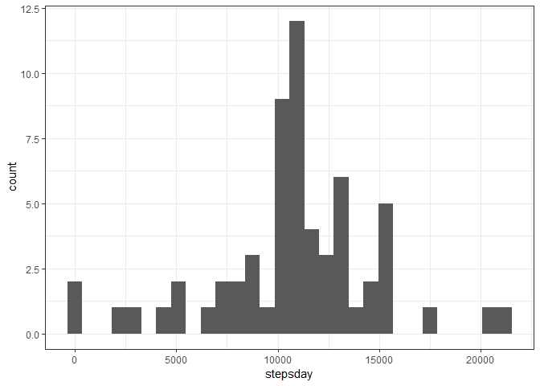

```r
act %>% group_by(date) %>%
        summarize(stepsday=sum(steps)) %>%
        ggplot(aes(x=stepsday))+geom_histogram(bins = 30)+
        theme_bw()
```

```r
act %>% group_by(date) %>%
        summarize(stepsday=sum(steps)) %>%
        summarize(mean=mean(stepsday), median=median(stepsday))
```

```
## # A tibble: 1 x 2
##     mean median
##    <dbl>  <dbl>
## 1 10766. 10766.
```

## Are there differences in activity patterns between weekdays and weekends?

```r
head(weekdays(act$date))
```

[output not shown]

```r
Sys.setlocale('LC_ALL','C')
```

```
## [1] "C"
```

```r
act <- act %>% mutate(week=ifelse(weekdays(date)%in%c("Monday", "Tuesday", "Wednesday", "Thursday", "Friday"), "Weekend", "Weekday"))
table(act$week)
```

[output not shown]

2. Make a panel plot containing a time series plot of the 5-minute interval (x-axis) and the average number of steps taken, averaged across all weekday days or weekend days (y-axis)

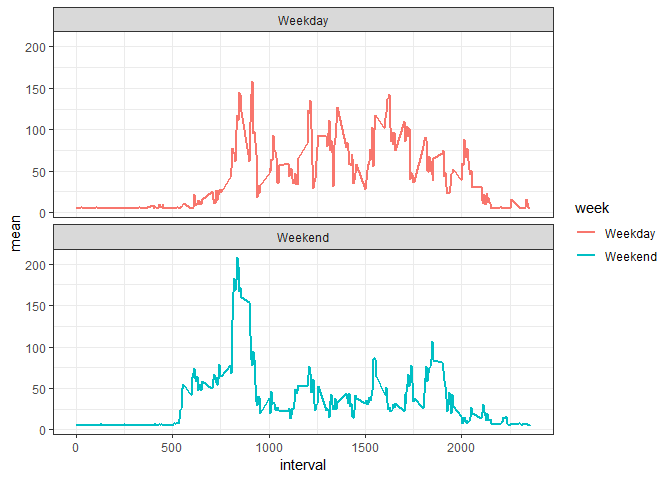

```r
act %>% group_by(week, interval) %>%
        summarize(mean=mean(steps, na.rm=TRUE)) %>%
        ggplot(aes(x=interval, y=mean, color=week))+
        geom_line(size=1)+
        facet_wrap(~week, ncol=1, nrow = 2)+
        theme_bw()
```